# User Guide

Jiri Hron (jiri.m.hron@gmail.com)

Support vector machines are one of today’s most popular machine learning algorithms. This application is giving users a possibility to try out and hopefully better understand SVMs’ behavior.

## About application

The following part of this guide is giving a very brief introduction into Support Vector Machines. If you are already familiar with SVMs, you can start using the application following these simple steps:

1. Generate two sample groups of points in 2D space, which will then be presented as training sample to SVM. To generate such data, `rnorm` function is used with following parameters specified by user:
   1. specify mean x1 values of groups A and B (value must be between 0 and 7),
   2. specify mean x2 values of groups A and B (value must be between 0 and 7),
   3. specify standard deviation for groups A and B (common for both dimensions) (value must be between 0.1 and 2),
   4. optionally specify seed for reproducibility (value must be between 0 and 1073741824).
2. Specify the cost of violation of margin.
3. Pick the kernel function (you can only pick from Linear or Gaussian kernel)
   1. if you pick Gaussian kernel, you can choose size of standard deviation for this function:

   $f^{(i)} = K\big(x_0, x_1\big) = exp\Big(-{\frac{\|x_0 - x_1\|}{2\sigma^2}}\Big)$

   (Value must be between 0.1 and 2)
4. Train the SVM on all of the generated observations and observe separation of of the feature space by virtual line created by different colors of point at a grid (small dots). Bigger dots are originally generated observations. Point which are surrounded by little triangles are support vectors.

Application is using `C-svc` type of classification parametrized by $C$. SVM implementation used is `ksvm` function from `kernlab` package.

## Introduction to SVMs

### Disclaimer

Following text is a very vague adaptation of Andrew Ng’s explanation of SVMs as taught in Machine Learning class at Coursera (2014). I am aware that many of the details are missing or might seem over-simplified (e.g. not mentioning dot products), and would not recommend anyone to who would really like to understand SVMs to start with this text. If you would like to do some adjustments on the application or this document, either send me an email, or simply fork this application at https://github.com/jiri-hron/SVMs.

For those interested in this topic I would personally recommend these resources:

1. [Machine Learning course by Andrew Ng](https://www.coursera.org/course/ml)
2. [Introduction to Statistical Learning (James et al., 2013)](http://www-bcf.usc.edu/~gareth/ISL/), p. 337-359
3. [Elements of Statistical Learning (Hastie et al., 2009)](http://statweb.stanford.edu/~tibs/ElemStatLearn/), p. 417-454 (advanced)

Caveat: The first resource is using slightly different terminology, e.g. tuning parameter $C$ by prof. Ng is used to penalize training observations for violating the margin, whereas other two resources uses $C$ as a “budget” for how many training observations are allowed to violate the margin, and thus $C$ has opposite interpretations in relation to the optimization problem and bias-variance trade-off.

For anyone reading the following paragraphs, they stick with prof. Ng’s definition which presumably stemms from the original definition by (Vapnik, 1979).

### Support vector machines

Support vector machines are basically a generalization of *maximum margin classifiers* concept, which is trying to find a best separating hyper-plane w.r.t. to the training data set. By best separating, we mean such with the largest possible margin. To illustrate this, look at the following figure:

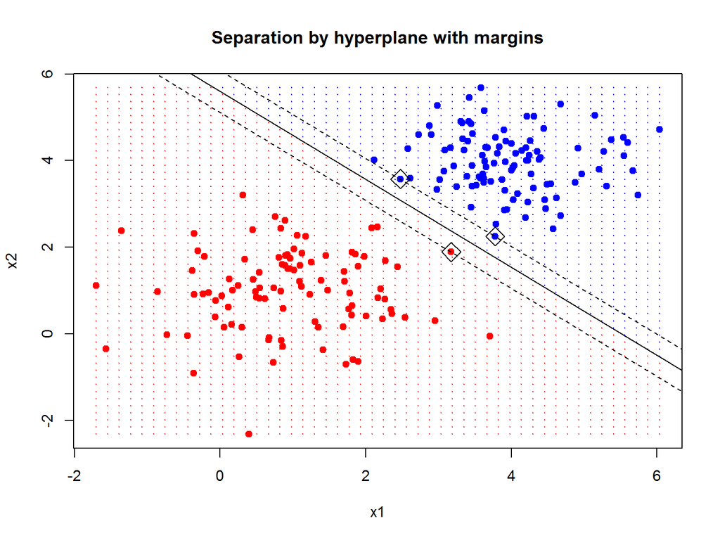

Here the solid black line shows a separating hyper-plane (which is in 2D a line), and dashed lines are showing the borders of the margin (margin is the space between both dashed lines). As you can see in this case, size of the margin is fully dependent only on a few points closest to the margin.

This concept of being dependent on only a few of training observations can produce relatively much more robust classifiers than such algorithms as linear discriminant analysis or logistic regression.

To find such separating hyper-plane, we are trying to solve this optimization problem:

$min_\theta C \sum_{i=1}^m \Big[ y^{(i)} cost_1(\theta^T f^{(i)}) + (1 - y^{(i)}) cost_0 (\theta^T f^{(i)}) \Big] + \frac{1}{2} \sum_{i=1}^n \theta_j^2$

where $m$ is a number of observations in the training set (number of rows of training set matrix), $n$ is a number of features (in the case of SVMs this is equal to $m$ - will be described), $y^{(i)}$ is a group to which $i^{th}$ observation belongs ($y^{(i)} \in \{0,1\}$), $C$ is a tuning parameter which virtually gives the cost of any observation violating its corresponding margin (will be described), $(cost_1, cost_0)$ give cost of classification of $i^{th}$ training observation to group 1 and 0 zero respectively, $f^{(i)}$ is a kernel function used to transform values of $x^{(i)}$-th based on other observations in the training set, and finally $\theta$ are parameters which should be learned by SVM in order to minimize the whole cost function.

To understand $f^{(i)}$, let’s look at following figure:

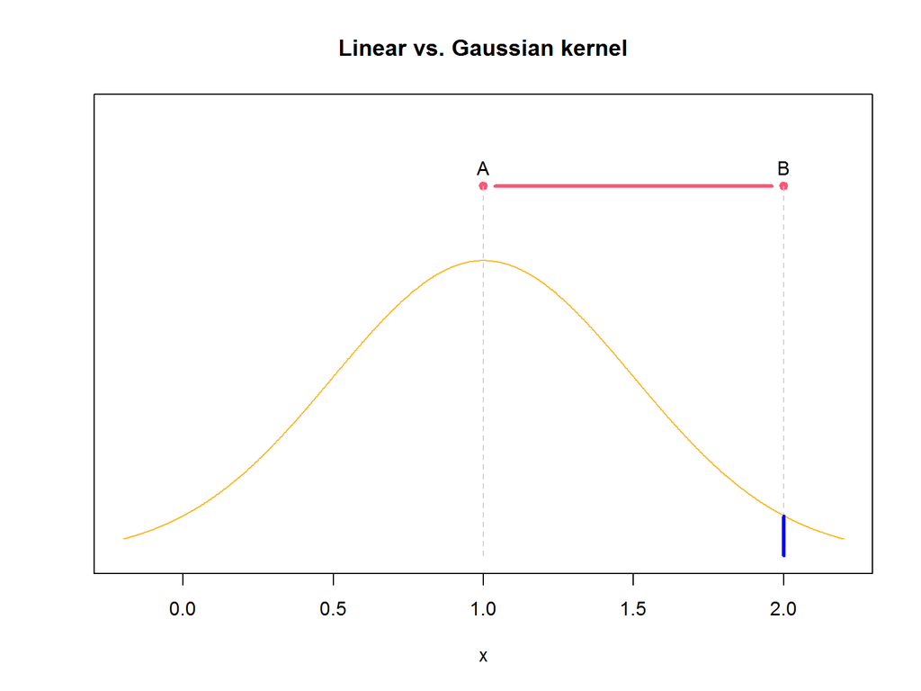

What you can see are measures of similarity used by Linear and Gaussian kernel. When using a linear kernel, we simply say that two points are similar to each other, if they are situated close to each other. With Gaussian kernel, we basically evaluate similarity of other points based on the probability they are stemming from the same Gaussian distribution.  
In the figure above, similarity of point B to point A is depicted by blue and red lines. You can imagine linear kernel’s measure of similarity as proportional to an inverse of the Euclidean distance between the two points. On the other hand, Gaussian kernel’s measure of similarity is directly proportional to the probability of point B in respect to Gaussian distribution with mean and at point A and some standard deviation $\sigma$ (this is a tuning parameter you can specify in the application).

Notice that we are calculating the similarity measure for each of the pairs of points in the training data set, that means $m \choose 2$ where $m$ is the number of observations in the training set. In other words, the feature vector for $i^{th}$ observation is of length $m$ (more precisely $m + 1$, with plus one dimension for the intercept). This explains our previous claim that in the case of SVMs, $m$ is equal to $n$ (number of features) in the regularization part of optimization formula $\sum_{i=1}^n \theta_j^2$ (as usual we do not penalize the intercept).

Eventually, we need to estimate vector $\theta$ in order to minimize the problem stated in the optimization problem. This problem involves functions $cost_1$ and $cost_0$, which state cost of classification of observation $i$ to the category $1$, resp $0$. SVMs use [Hinge loss function](http://en.wikipedia.org/wiki/Hinge_loss) which is somewhat similar to the cost function of logistic regression, apart from assigning cost $0$ for all training points which are on the “correct” side of the margin, and penalty for training points which are on the correct side of the decision boundary (hyperplane), but are violating the margin (two zones between solid line and dashed lines in the first plot, one for each of the categories). It can be shown, that elements of $\theta$ under such conditions are non-zero only for support vectors, if $\theta$ is optimal.

What are support vectors? If you return back to the first plot on this page, you will see that some of the points do have around them small rectangles. You could also notice, that all of these points are lying directly on the margin borders (shown by dashed lines). Generally, support vectors are all points, that lies directly at or at the wrong side of the respective margin border.

This leads back to the notion of maximum margin classifiers from which SVMs were developed. We are not only trying to find a classifier, that would be able to find decision boundary which correctly predicts each observation’s class, but we would also like to find such decision boundary that would be as much confident at its predictions as possible. This basically equals to finding a hyperplane which would separate the data in such manner, that their distance to the boundary is maximal.

You can directly influence size of the margin by adjusting the tuning parameter $C$. With growing $C$, you are assigning a bigger penalty for each training observation that violates (crosses) the margin. This could naturally lead to over-fitting. On the other hand, if $C$ is small, you don’t really care about some of the observations crossing the margin, and thus you can make the margin wider, even though more of the training observations would violate it, because it will become wider. Wider margin can be more robust, but can also underfit the data (high bias).

Finally, what is the difference between fitting SVM with Linear and with Gaussian kernels? Basically, Linear kernel can only produce linear separating hyperplanes, whereas Gaussian kernel can fit also non-linear hyperplanes. Linear kernels are out-performing other types of kernels in cases where the data are in fact linearly separable or in high-dimensional problems. Gaussian kernels on the other hand can prove very useful in many cases where there is no clear boundary between each of the response vector categories, or when the data cannot be separated by linear, but can be separted by non-linear boundary.